# Homework 2

Martha Wetzel

2/21/2018

# *Due Date* is 21 February 2018

This homework is meant to further your `dplyr` and `ggplot2` skills.

First, install the package

- `car`

## Installing the `car` package

We found some hiccups when we were designing this homework. With a little sleuthing, we were able to figure out that some of the issues related to installing the package and dependent package called `quantreg`. So before you install `car` use the following R commands:

- install.packages(“quantreg”, dependencies=TRUE)
- install.packages(“car”, dependencies=TRUE)

You might get this question in the console:

“Do you want to install from sources the package which needs compilation” followed by a prompt for you to respond yes or no, which looks like

`y/n:`

Usually when you see this prompt in RStudio, `y` is a good default response. However when installing `quantreg` and `car`, we found that if you answered `n` to the prompts, all will work well. *(answering `y` here leads to other issues you can avoid for now… we don’t want you to descend into R purgatory, LOL)*

## The Data - `Davis` dataset in the `car` package

The `Davis` dataset in the `car` package contains data on the measured and reported heights and weights of men and women engagedin regular exercise. *[For more information, type `?car::Davis` in the Console to bring up the HELP pages on the `Davis` dataset in the `car` package.]*

Use tools within the `dplyr` package as much as possible to answer the following questions.

##### **Question 1:** What kind of R object is the `Davis` dataset?

```r
library(car)
library(quantreg)
library(dplyr)
library(ggplot2)
library(janitor)
data(Davis)
ls()
```

```
## [1] "Davis"
```

The Davis data set is a data.frame object

##### **Question 2:** How many observations are in the `Davis` dataset?

```r
str(Davis)
```

```
## 'data.frame':    200 obs. of  5 variables:
##  $ sex   : Factor w/ 2 levels "F","M": 2 1 1 2 1 2 2 2 2 2 ...
##  $ weight: int  77 58 53 68 59 76 76 69 71 65 ...
##  $ height: int  182 161 161 177 157 170 167 186 178 171 ...
##  $ repwt : int  77 51 54 70 59 76 77 73 71 64 ...
##  $ repht : int  180 159 158 175 155 165 165 180 175 170 ...
```

```r
Davis %>%
  summarise(nObs = n())
```

```
##   nObs
## 1  200
```

There are 200 observations in the Davis data set.

##### **Question 3:** For reported weight, how many observations have a missing value?

```r
completeObs <- complete.cases(Davis$weight)
```

**There are 0 missing weight values.**

##### **Question 4:** How many observations have no missing values? *(HINT: find complete cases)*

```r
CompleteRecs <- complete.cases(Davis)
```

**There are 181 complete records.**

##### **Question 5:** How many females are in this subset?

Create a subset containing only females.

```r
Females <- Davis %>%
  filter(sex == "F")
```

**There are 112 females in the Davis data.**

That last question was an opportunity for you to show-off your `dplyr` confidence.

*Now* return to the overall dataset with both males and females.

Body mass index is one way to quantify the amount of tissue mass (muscle, fat, and bone) in an individual, then categorize that person as *underweight*, *normal* *weight*, *overweight*, or *obese* according to that value.

We calculate the BMI as the **ratio of the weight in kilograms divided by the square of the height in meters**, and the categorization based on BMI is as follows:

### BMI Categories

| Category | BMI range (kg/m2) |
| --- | --- |
| Underweight | <18.5 |
| Normal | 18.5 to <25 |
| Overweight | 25 to <30 |
| Obese | 30 or higher |

Create the BMI variable and then a variable to depict BMI category. Note that the `height` variable is in centimeters, and `weight` is in kg. You need to create the BMI variable using the correct formula.

```r
heightm <- Davis$height/100
BMI <- Davis$weight/(heightm^2)

Davis <- Davis %>%
  mutate(BMIcat =
    if_else(BMI < 18.5, "1. Underweight",
                                         if_else( BMI<25, "2. Normal",
                                                                    if_else(BMI < 30, "3. Overweight", "4. Obese"))))

Davis$BMI_NoOutlier <-  BMI
Davis$BMI_NoOutlier[BMI>300] <- NA
```

Now answer these questions:

##### **Question 6:** What is the average BMI for these individuals?

**The average BMI for these individuals is 24.7.** However, this average includes a clearly incorrect extreme value. When this extreme value is removed, the mean is 22.26.

##### **Question 7:** How do these individuals fall into the BMI categories (what are the frequencies and relative %’s)?

```r
Davis %>%
  janitor::tabyl(BMIcat)
```

```
##           BMIcat   n percent
## 1 1. Underweight  18   0.090
## 2      2. Normal 143   0.715
## 3  3. Overweight  35   0.175
## 4       4. Obese   4   0.020
```

## Test your graphing skills using `ggplot2`

Using the `Davis` dataset from the `car` package, create the following graphics/figures using `ggplot()` and associated `geom_xxx()` functions.

##### **Question 8:** Create a histogram of BMI.

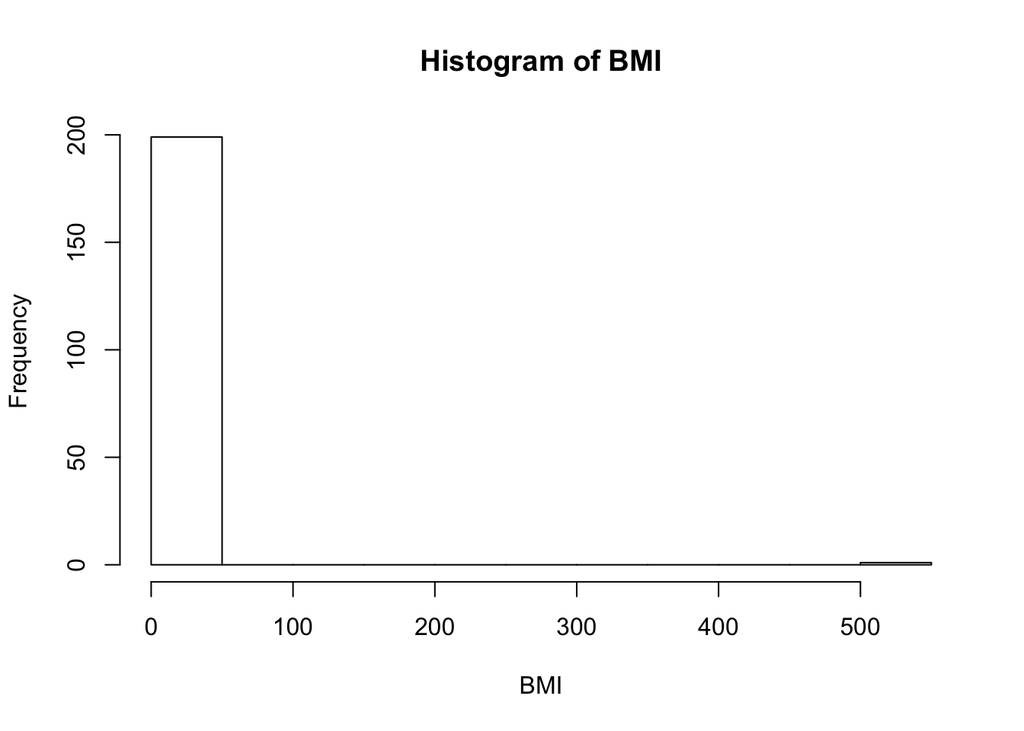

```r
hist(BMI)
```

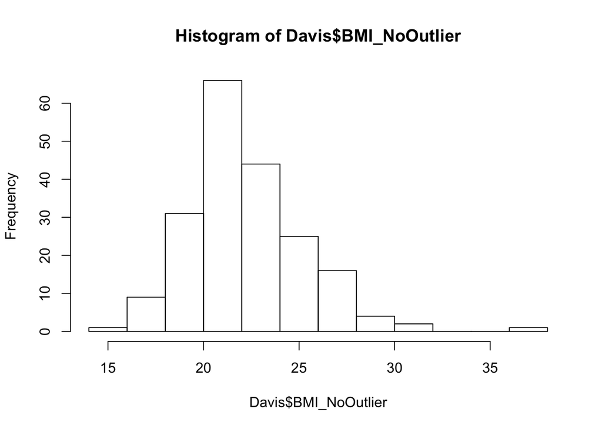

```r
hist(Davis$BMI_NoOutlier)
```

*What do you notice about the distribution (any outliers or skewness)?* When the extreme outlier is removed, the distribution retains some right-skewness with an outlier, but it does appear to approximate normality.

##### **Question 9:** Create side-by-side boxplots of the BMI distributions by gender

*Remember to remove any outliers if needed*

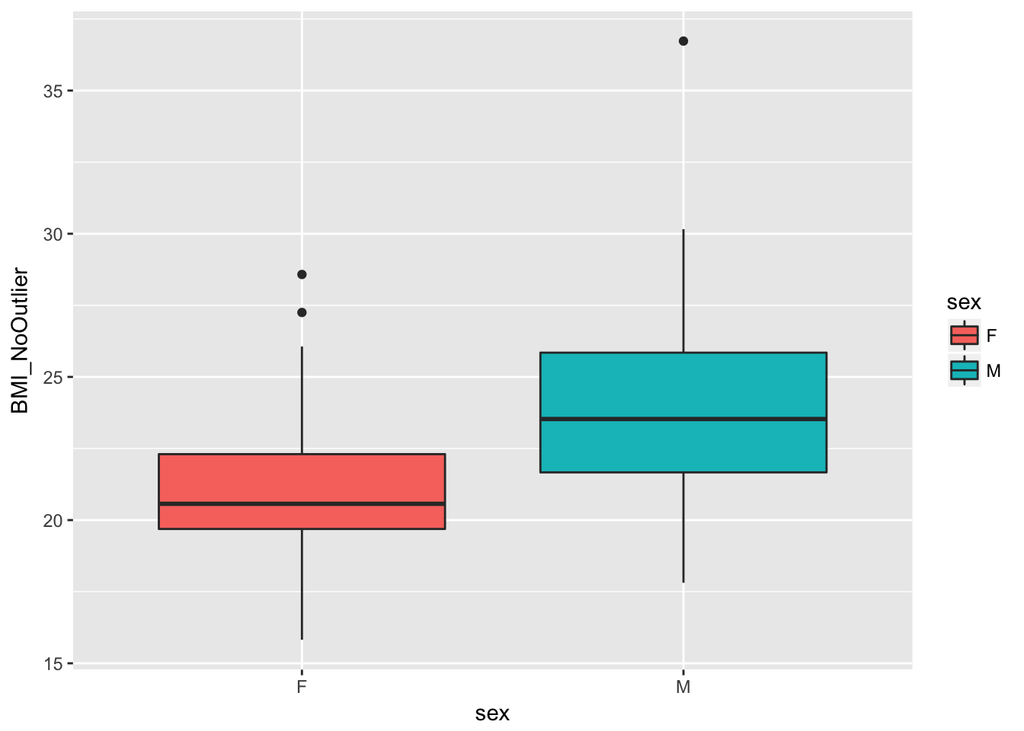

```r
ggplot(Davis,
       aes(x=sex, y=BMI_NoOutlier, fill=sex)) +
  geom_boxplot()
```

##### **Question 10:** Create a clustered bar chart of the BMI categories by gender

*(note: the y-axis should be counts)*

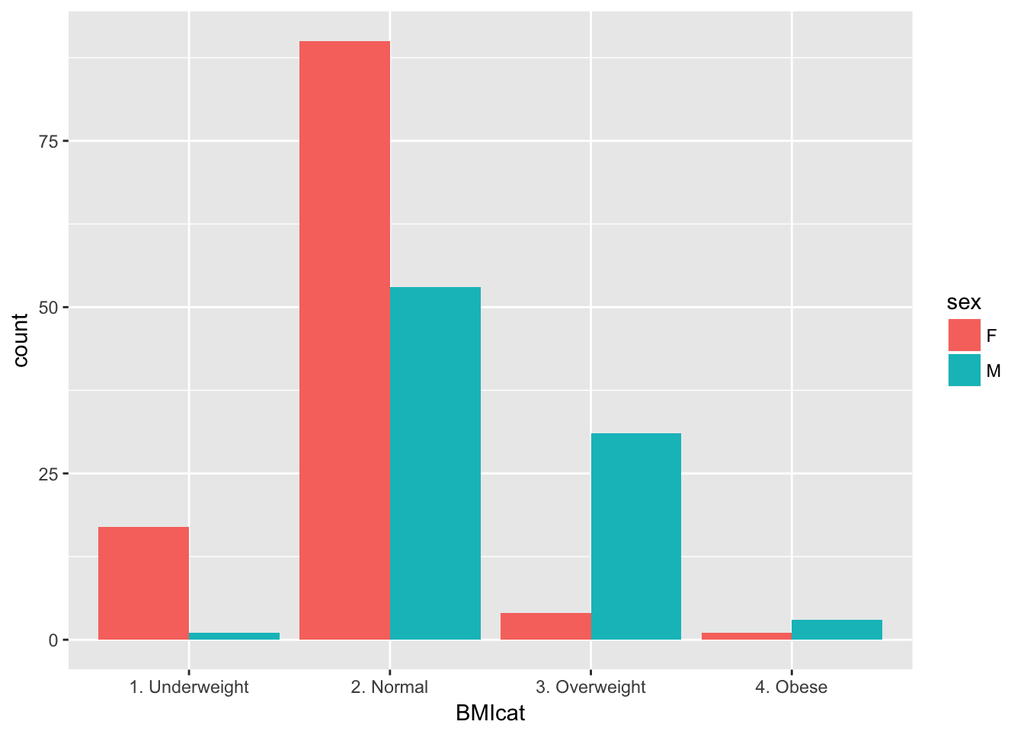

```r
Davis %>% ggplot(aes(x=BMIcat, fill=sex)) +
  geom_bar(position = "dodge")
```

Note: This homework can be found in [this online GitHub repository](https://github.com/mpwetzel1/N741Homework2)